# Analysis Report

LAN

2024-06-13

# Summary Statistics

Summary Statistics: Mean (average value), SD (standard deviation), Median (middle value), IQR (interquartile range). These statistics provide insights into the central tendency and variability of counts across different methods and severity levels.

## Interpretation

The summary statistics provide a snapshot of the central tendency and variability of the counts for each method and severity level.

- Method 4:
  - Mean counts across severity levels range from 8481 to 9492.
  - High variability (SD) indicates fluctuating estimates.
- Method 5:
  - Mean counts are significantly higher (14,163 to 15,963).
  - High variability (SD), particularly for severity 3 (SD = 14,007), indicates fluctuating estimates for level3.
- Method 6:
  - Mean counts are lower (5,073 to 5,146).
  - Lower variability (SD) suggests a more consistent estimates.

```
## Structure of the data frame:
```

```
## Data based on Method 4 - Maximum Sector PiN distribution
```

```
## 'data.frame':    335 obs. of  10 variables:
##  $ Admin.2.Pcode: chr  "YE1209" "YE1201" "YE1208" "YE1203" ...
##  $ population   : int  76870 5803 59439 15632 19335 2718 90532 80704 64814 47798 ...
##  $ Sector       : chr  "Shelter" "Health" "WASH" "WASH" ...
##  $ pin          : int  62449 5119 44518 14514 19133 2403 53533 77522 45004 46221 ...
##  $ severity     : int  1 5 5 2 3 3 2 4 1 2 ...
##  $ dummy_pin_1  : int  31224 606 5671 1796 2408 287 6719 9628 22502 5775 ...
##  $ dummy_pin_2  : int  7860 628 5608 7257 2390 297 26766 9787 5578 23110 ...
##  $ dummy_pin_3  : int  7779 651 5525 1874 9566 1202 6598 9614 5584 5692 ...
##  $ dummy_pin_4  : int  7759 674 5455 1823 2306 316 6734 38761 5650 5798 ...
##  $ dummy_pin_5  : int  7827 2560 22259 1764 2463 301 6716 9732 5690 5846 ...
```

```
## Data based on Method 5 - mosaic method stop at level3
```

```
## 'data.frame':    335 obs. of  8 variables:
##  $ Admin.2.Pcode             : chr  "YE1101" "YE1102" "YE1103" "YE1104" ...
##  $ dummy_pin_5_max           : int  29462 7744 15290 1406 8986 19073 1258 4726 38134 37060 ...
##  $ dummy_pin_4_max           : int  8104 7668 18280 3444 5871 13658 1266 2169 37012 9542 ...
##  $ dummy_pin_3_max           : int  26798 46102 31612 6112 31996 12732 7451 10008 8825 29364 ...
##  $ overall_pin               : int  64364 61514 65182 10962 46853 45463 9975 16903 83971 75966 ...
##  $ dummy_pin_5_max_percentage: num  45.8 12.6 23.5 12.8 19.2 ...
##  $ dummy_pin_4_max_percentage: num  12.6 12.5 28 31.4 12.5 ...
##  $ dummy_pin_3_max_percentage: num  41.6 74.9 48.5 55.8 68.3 ...
```

```
## Data based on Method 6 - Mean/Median stop at level3 (Level 3 is residual)
```

```
## 'data.frame':    335 obs. of  8 variables:
##  $ Admin.2.Pcode     : chr  "YE1101" "YE1102" "YE1103" "YE1104" ...
##  $ dummy_pin_5_avg   : num  8170 2825 5804 748 4176 ...
##  $ dummy_pin_4_avg   : num  4978 2766 8615 1130 3359 ...
##  $ dummy_pin_3_avg   : num  11112 7350 3963 1311 5614 ...
##  $ dummy_pin_5_median: num  6305 1104 4575 623 4408 ...
##  $ dummy_pin_4_median: num  6216 858 6908 918 3053 ...
##  $ dummy_pin_3_median: num  6274 2178 4134 721 5129 ...
##  $ overall_pin       : int  64364 61514 65182 10962 46853 45463 9975 16903 83971 75966 ...
```

```
## # A tibble: 6 × 4
##   Admin.2.Pcode Severity Count Method
##   <chr>            <int> <dbl> <chr>
## 1 YE1209               1 31224 method4
## 2 YE1209               2  7860 method4
## 3 YE1209               3  7779 method4
## 4 YE1209               4  7759 method4
## 5 YE1209               5  7827 method4
## 6 YE1201               1   606 method4
```

```
## # A tibble: 11 × 6
## # Groups:   Method [3]
##    Method  Severity   Mean     SD Median    IQR
##    <chr>      <int>  <dbl>  <dbl>  <dbl>  <dbl>
##  1 method4        1  8481.  8778.  6324   6350.
##  2 method4        2  9221.  9164.  6926   6482.
##  3 method4        3  8706.  9086.  6239   6206.
##  4 method4        4  9098.  9487.  6270   6961
##  5 method4        5  9492.  9831.  6668   6522.
##  6 method5        3 15963. 14007. 11637  18654.
##  7 method5        4 14163. 11077. 10992  16512.
##  8 method5        5 14872. 11523. 11398  16596.
##  9 method6        3  5073.  3403.  4789.  4443
## 10 method6        4  5099.  3550.  4472.  4781
## 11 method6        5  5146.  3358.  4696.  4914.
```

# Test 2: ANOVA Test

## ANOVA Results:

- **The significant effect of Method (p < 2e-16) indicates significant differences between methods**
- **The interaction between Method and Severity is not significant (p = 0.163), suggesting that differences between methods do not vary significantly across severity levels.**
- **Severity alone is not significant (p = 0.637), indicating no substantial difference in counts across severity levels regardless of method.**

```
##                   Df    Sum Sq   Mean Sq F value Pr(>F)
## Method             2 5.020e+10 2.510e+10 300.936 <2e-16 ***
## Severity           1 1.858e+07 1.858e+07   0.223  0.637
## Method:Severity    2 3.028e+08 1.514e+08   1.815  0.163
## Residuals       3679 3.068e+11 8.341e+07
## ---
## Signif. codes:  0 '***' 0.001 '**' 0.01 '*' 0.05 '.' 0.1 ' ' 1
```

Footnote: ANOVA: Method tests for significant differences between methods; Severity examines differences across severity levels; Method:Severity tests for interaction effects; Residuals represent unexplained variation.

# Test 3: Visulization

## Visualizations

- Boxplot: Shows the distribution of counts by method and severity level.
  - Method 5 tends to have higher counts and **wider variability**.
  - Method 6 shows more **consistent** counts with **lower median values**.
  - Method 4 shows intermediate counts with **moderate variability**.
- Density Plot: Illustrates the distribution of counts across methods for each severity level.
  - Distinct distributions are observed, supporting the K-S test results indicating significant differences between methods.

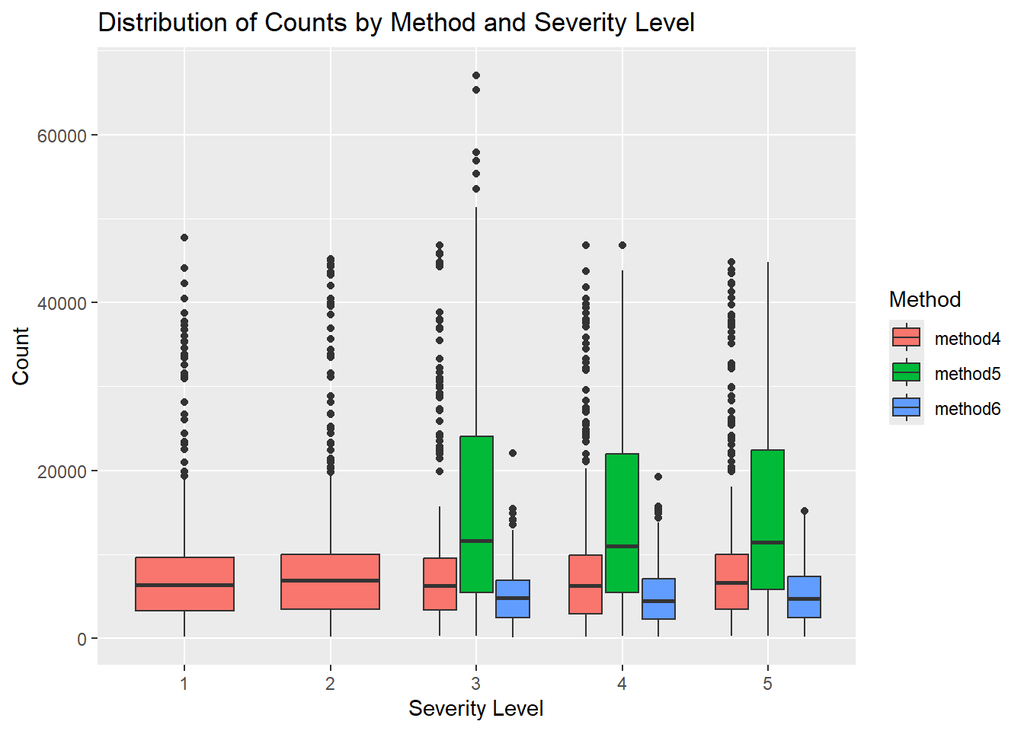

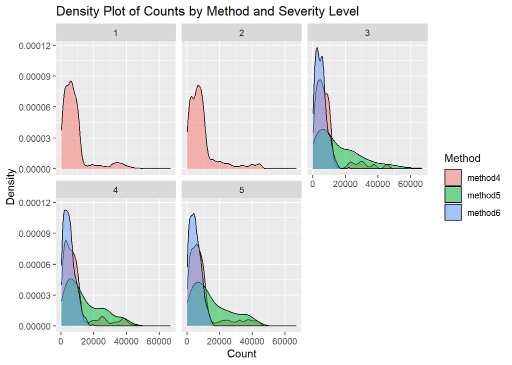

Footnote: Visualizations: Boxplot provides distribution characteristics by severity and method; Density plot illustrates density distribution for each method and severity level.

# Test 4: Goodness-of-fit test (Chi-squared test)

## Goodness-of-Fit (Chi-squared)

```
Chi-squared Results:
    Method 4: ChiSq = 57,820
    Method 5: ChiSq = 2,886,028
    Method 6: ChiSq = 2,213,240
```

```
## # A tibble: 3 × 2
##   Method     ChiSq
##   <chr>      <dbl>
## 1 method4   57820.
## 2 method5 2886028.
## 3 method6 2213240.
```

# Test 5: Perform Kolmogorov-Smirnov test between methods

## Kolmogorov-Smirnov Test

```
P-values:
    Method4 vs Method5: p = 1.535949e-60
    Method4 vs Method6: p = 1.049617e-23
    Method5 vs Method6: p = 4.517653e-91
```

### Interpretation:

- All p-values are extremely low, indicating significant differences between the distributions of counts for all method pairs.
- **This suggests that the distributions generated by the three methods are statistically different from each other**

```
## $method4_vs_method5
## [1] 1.535949e-60
##
## $method4_vs_method6
## [1] 1.049617e-23
##
## $method5_vs_method6
## [1] 4.517653e-91
```

Footnote: Kolmogorov-Smirnov Test: P-values indicate whether distributions between methods are significantly different. Lower values suggest significant differences.

# Test 6: Intraclass correlation coefficient (ICC)

## Intraclass Correlation Coefficient (ICC)

```
ICC Result:
    ICC = 0.686 (95% CI: 0.653 - 0.717)
    F-Test p-value: 2.95e-130
```

### Interpretation:

- An ICC value of 0.686 indicates **good consistency** among the methods, though not excellent (generally, >0.75 is considered excellent).
- The confidence interval suggests that the consistency is **reliably above moderate**.

```
##  Average Score Intraclass Correlation
##
##    Model: twoway
##    Type : consistency
##
##    Subjects = 1005
##      Raters = 4
##    ICC(C,4) = 0.686
##
##  F-Test, H0: r0 = 0 ; H1: r0 > 0
## F(1004,3012) = 3.19 , p = 2.95e-130
##
##  95%-Confidence Interval for ICC Population Values:
##   0.653 < ICC < 0.717
```

Footnote: Intraclass Correlation Coefficient (ICC): ICC values assess consistency among methods. Higher values (>0.75) indicate better agreement.

# Overall Conclusion

- Method 4 shows **intermediate variability**.
- Method 5 generates higher counts with **significant variability**, which might be desirable for the context.
- Method 6 offers lower counts with **more consistency**, less variability than method 5, which could be advantageous if stability is a priority.

**Ultimately, the choice of the most appropriate method depends on the experts opinion and the context and criteria such as fit, consistency, and count levels**